# Statistical Inference Course Project Part. 1

> The exponential distribution can be simulated in R with rexp(n, lambda) where lambda is the rate parameter. The mean of exponential distribution is 1/lambda and the standard deviation is also also 1/lambda. Set lambda = 0.2 for all of the simulations. In this simulation, you will investigate the distribution of averages of 40 exponential(0.2)s. Note that you will need to do a thousand or so simulated averages of 40 exponentials.

> Illustrate via simulation and associated explanatory text the properties of the distribution of the mean of 40 exponential(0.2)s. You should  
> 1. Show where the distribution is centered at and compare it to the theoretical center of the distribution.  
> 2. Show how variable it is and compare it to the theoretical variance of the distribution.  
> 3. Show that the distribution is approximately normal.

## Processing Data

```r
set.seed(12345)
itemSize = 1000
sampleSize = 40
lambda = .2
mat = matrix(rexp(itemSize * sampleSize, rate = lambda), nrow = itemSize, ncol = sampleSize)
items = rowMeans(mat)
```

## Results

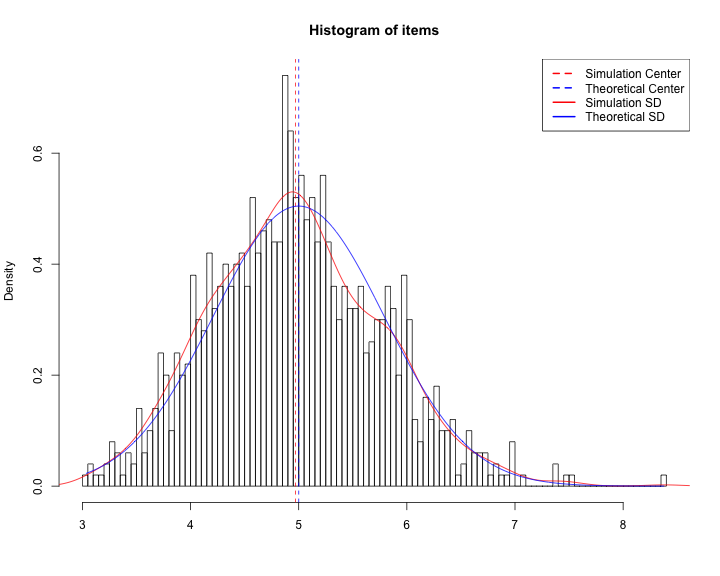

```r
simMean = round(mean(items), digit = 2)
theoMean = 1/lambda
simVar = round(var(items), digit = 2)
theoVar = (1/lambda)^2 / sampleSize

hist(items, breaks = 100, prob=TRUE, xlab = NULL)
lines(density(items), lwd = 1, col = "red", lty = "solid")
abline(v = simMean, lwd = 1, col = "red", lty = "dashed")
abline(v = theoMean, lwd = 1, col = "blue", lty = "dashed")

normal.x = seq(min(items), max(items), length = itemSize)
normal.y = dnorm(normal.x, mean = 1/lambda, sd = (1/lambda)/sqrt(sampleSize))
lines(normal.x, normal.y, lwd = 1, col = "blue", lty = "solid")
legend("topright", c("Simulation Center", "Theoretical Center", "Simulation SD", "Theoretical SD"), lty=c("dashed", "dashed", "solid", "solid"), lwd=2, col = c("red", "blue", "red", "blue"))
```

### Center of the distribution.

**Center of the distribution from simulation is *4.97* and theoretical center of the distribution is *5*.**

### Variances

**Variance from simulation is *0.62* and theoretical variance is *0.625*.**

### The distribution is approximately normal.

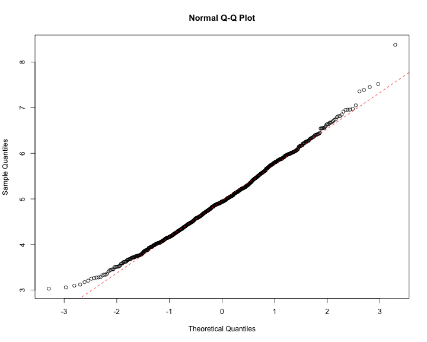

```r
qqnorm(items); qqline(items, col = "red", lty = "dashed")
```